# Risk Factor Analysis

## Outcome Variable

**Outcome Variable:** ever_wasted

## Predictor Variables

**Intervention Variable:** feducyrs

**Adjustment Set:**

- arm
- W_mage
- meducyrs
- hhwealth_quart
- W_mhtcm
- W_mwtkg
- W_mbmi
- W_gagebrth
- W_birthwt
- W_birthlen
- single
- delta_W_mage
- delta_meducyrs
- delta_hhwealth_quart
- delta_W_mhtcm
- delta_W_mwtkg
- delta_W_mbmi
- delta_W_gagebrth
- delta_W_birthwt
- delta_W_birthlen
- delta_single

## Stratifying Variables

The analysis was stratified on these variable(s):

- agecat
- studyid
- country

## Data Summary

| agecat | studyid | country | feducyrs | ever_wasted | n_cell | n |
| --- | --- | --- | --- | --- | --- | --- |
| 0-24 months | COHORTS | GUATEMALA | High | 0 | 164 | 1234 |
| 0-24 months | COHORTS | GUATEMALA | High | 1 | 67 | 1234 |
| 0-24 months | COHORTS | GUATEMALA | Low | 0 | 419 | 1234 |
| 0-24 months | COHORTS | GUATEMALA | Low | 1 | 139 | 1234 |
| 0-24 months | COHORTS | GUATEMALA | Medium | 0 | 330 | 1234 |
| 0-24 months | COHORTS | GUATEMALA | Medium | 1 | 115 | 1234 |
| 0-24 months | COHORTS | INDIA | High | 0 | 386 | 1447 |
| 0-24 months | COHORTS | INDIA | High | 1 | 181 | 1447 |
| 0-24 months | COHORTS | INDIA | Low | 0 | 305 | 1447 |
| 0-24 months | COHORTS | INDIA | Low | 1 | 167 | 1447 |
| 0-24 months | COHORTS | INDIA | Medium | 0 | 269 | 1447 |
| 0-24 months | COHORTS | INDIA | Medium | 1 | 139 | 1447 |
| 0-24 months | COHORTS | PHILIPPINES | High | 0 | 640 | 2868 |
| 0-24 months | COHORTS | PHILIPPINES | High | 1 | 388 | 2868 |
| 0-24 months | COHORTS | PHILIPPINES | Low | 0 | 480 | 2868 |
| 0-24 months | COHORTS | PHILIPPINES | Low | 1 | 346 | 2868 |
| 0-24 months | COHORTS | PHILIPPINES | Medium | 0 | 597 | 2868 |
| 0-24 months | COHORTS | PHILIPPINES | Medium | 1 | 417 | 2868 |
| 0-24 months | GMS-Nepal | NEPAL | High | 0 | 65 | 684 |
| 0-24 months | GMS-Nepal | NEPAL | High | 1 | 104 | 684 |
| 0-24 months | GMS-Nepal | NEPAL | Low | 0 | 115 | 684 |
| 0-24 months | GMS-Nepal | NEPAL | Low | 1 | 177 | 684 |
| 0-24 months | GMS-Nepal | NEPAL | Medium | 0 | 100 | 684 |
| 0-24 months | GMS-Nepal | NEPAL | Medium | 1 | 123 | 684 |
| 0-24 months | JiVitA-3 | BANGLADESH | High | 0 | 4908 | 25970 |
| 0-24 months | JiVitA-3 | BANGLADESH | High | 1 | 1569 | 25970 |
| 0-24 months | JiVitA-3 | BANGLADESH | Low | 0 | 7799 | 25970 |
| 0-24 months | JiVitA-3 | BANGLADESH | Low | 1 | 2838 | 25970 |
| 0-24 months | JiVitA-3 | BANGLADESH | Medium | 0 | 6580 | 25970 |
| 0-24 months | JiVitA-3 | BANGLADESH | Medium | 1 | 2276 | 25970 |

[output cut: 330 more lines]

The following strata were considered:

- agecat: 0-24 months, studyid: COHORTS, country: GUATEMALA
- agecat: 0-24 months, studyid: COHORTS, country: INDIA
- agecat: 0-24 months, studyid: COHORTS, country: PHILIPPINES
- agecat: 0-24 months, studyid: GMS-Nepal, country: NEPAL
- agecat: 0-24 months, studyid: JiVitA-3, country: BANGLADESH
- agecat: 0-24 months, studyid: JiVitA-4, country: BANGLADESH
- agecat: 0-24 months, studyid: LCNI-5, country: MALAWI
- agecat: 0-24 months, studyid: MAL-ED, country: BANGLADESH
- agecat: 0-24 months, studyid: MAL-ED, country: INDIA
- agecat: 0-24 months, studyid: MAL-ED, country: NEPAL
- agecat: 0-24 months, studyid: MAL-ED, country: PERU
- agecat: 0-24 months, studyid: MAL-ED, country: SOUTH AFRICA
- agecat: 0-24 months, studyid: MAL-ED, country: TANZANIA, UNITED REPUBLIC OF
- agecat: 0-24 months, studyid: NIH-Crypto, country: BANGLADESH
- agecat: 0-24 months, studyid: PROBIT, country: BELARUS
- agecat: 0-24 months, studyid: PROVIDE, country: BANGLADESH
- agecat: 0-24 months, studyid: SAS-CompFeed, country: INDIA
- agecat: 0-24 months, studyid: SAS-FoodSuppl, country: INDIA
- agecat: 0-24 months, studyid: TanzaniaChild2, country: TANZANIA, UNITED REPUBLIC OF
- agecat: 0-24 months, studyid: ZVITAMBO, country: ZIMBABWE
- agecat: 0-6 months, studyid: COHORTS, country: GUATEMALA
- agecat: 0-6 months, studyid: COHORTS, country: INDIA
- agecat: 0-6 months, studyid: COHORTS, country: PHILIPPINES
- agecat: 0-6 months, studyid: GMS-Nepal, country: NEPAL
- agecat: 0-6 months, studyid: JiVitA-3, country: BANGLADESH
- agecat: 0-6 months, studyid: JiVitA-4, country: BANGLADESH
- agecat: 0-6 months, studyid: LCNI-5, country: MALAWI
- agecat: 0-6 months, studyid: MAL-ED, country: BANGLADESH
- agecat: 0-6 months, studyid: MAL-ED, country: INDIA
- agecat: 0-6 months, studyid: MAL-ED, country: NEPAL
- agecat: 0-6 months, studyid: MAL-ED, country: PERU
- agecat: 0-6 months, studyid: MAL-ED, country: SOUTH AFRICA
- agecat: 0-6 months, studyid: MAL-ED, country: TANZANIA, UNITED REPUBLIC OF
- agecat: 0-6 months, studyid: NIH-Crypto, country: BANGLADESH
- agecat: 0-6 months, studyid: PROBIT, country: BELARUS
- agecat: 0-6 months, studyid: PROVIDE, country: BANGLADESH
- agecat: 0-6 months, studyid: SAS-CompFeed, country: INDIA
- agecat: 0-6 months, studyid: SAS-FoodSuppl, country: INDIA
- agecat: 0-6 months, studyid: TanzaniaChild2, country: TANZANIA, UNITED REPUBLIC OF
- agecat: 0-6 months, studyid: ZVITAMBO, country: ZIMBABWE
- agecat: 6-24 months, studyid: COHORTS, country: GUATEMALA
- agecat: 6-24 months, studyid: COHORTS, country: INDIA
- agecat: 6-24 months, studyid: COHORTS, country: PHILIPPINES
- agecat: 6-24 months, studyid: GMS-Nepal, country: NEPAL
- agecat: 6-24 months, studyid: JiVitA-3, country: BANGLADESH
- agecat: 6-24 months, studyid: JiVitA-4, country: BANGLADESH
- agecat: 6-24 months, studyid: LCNI-5, country: MALAWI
- agecat: 6-24 months, studyid: MAL-ED, country: BANGLADESH
- agecat: 6-24 months, studyid: MAL-ED, country: INDIA
- agecat: 6-24 months, studyid: MAL-ED, country: NEPAL
- agecat: 6-24 months, studyid: MAL-ED, country: PERU
- agecat: 6-24 months, studyid: MAL-ED, country: SOUTH AFRICA
- agecat: 6-24 months, studyid: MAL-ED, country: TANZANIA, UNITED REPUBLIC OF
- agecat: 6-24 months, studyid: NIH-Crypto, country: BANGLADESH
- agecat: 6-24 months, studyid: PROBIT, country: BELARUS
- agecat: 6-24 months, studyid: PROVIDE, country: BANGLADESH
- agecat: 6-24 months, studyid: SAS-CompFeed, country: INDIA
- agecat: 6-24 months, studyid: SAS-FoodSuppl, country: INDIA
- agecat: 6-24 months, studyid: TanzaniaChild2, country: TANZANIA, UNITED REPUBLIC OF
- agecat: 6-24 months, studyid: ZVITAMBO, country: ZIMBABWE

### Dropped Strata

Some strata were dropped due to rare outcomes:

- agecat: 0-24 months, studyid: MAL-ED, country: PERU
- agecat: 0-24 months, studyid: MAL-ED, country: TANZANIA, UNITED REPUBLIC OF
- agecat: 0-6 months, studyid: LCNI-5, country: MALAWI
- agecat: 0-6 months, studyid: MAL-ED, country: NEPAL
- agecat: 0-6 months, studyid: MAL-ED, country: PERU
- agecat: 0-6 months, studyid: MAL-ED, country: SOUTH AFRICA
- agecat: 0-6 months, studyid: MAL-ED, country: TANZANIA, UNITED REPUBLIC OF
- agecat: 6-24 months, studyid: MAL-ED, country: NEPAL
- agecat: 6-24 months, studyid: MAL-ED, country: PERU
- agecat: 6-24 months, studyid: MAL-ED, country: SOUTH AFRICA
- agecat: 6-24 months, studyid: MAL-ED, country: TANZANIA, UNITED REPUBLIC OF

## Methods Detail

We're interested in the causal parameters $E[Y_a]$ for all values of $a \in \mathcal{A}$. These parameters represent the mean outcome if, possibly contrary to fact, we intervened to set all units to have $A=a$. Under the randomization and positivity assumptions, these are identified by the statistical parameters $\psi_a=E_W[E_{Y|A,W}(Y|A=a,W)]$. In addition, we're interested in the mean of $Y$, $E[Y]$ under no intervention (the observed mean). We will estimate these parameters by using SuperLearner to fit the relevant likelihood factors -- $E_{Y|A,W}(Y|A=a,W)$ and $p(A=a|W)$, and then updating our likelihood fit using a joint TMLE.

For unadjusted analyses ($W=\{\}$), initial likelihoods were estimated using Lrnr_glm to estimate the simple $E(Y|A)$ and Lrnr_mean to estimate $p(A)$. For adjusted analyses, a small library containing Lrnr_glmnet, Lrnr_xgboost, and Lrnr_mean was used.

Having estimated these parameters, we will then use the delta method to estimate relative risks and attributable risks relative to a prespecified baseline level of $A$.

# Results Detail

## Results Plots

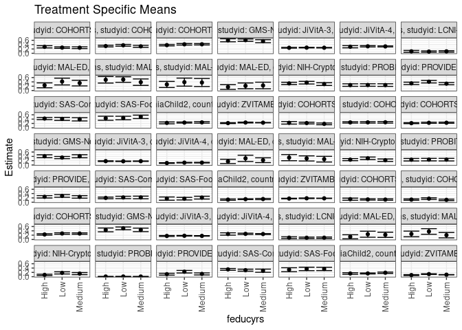

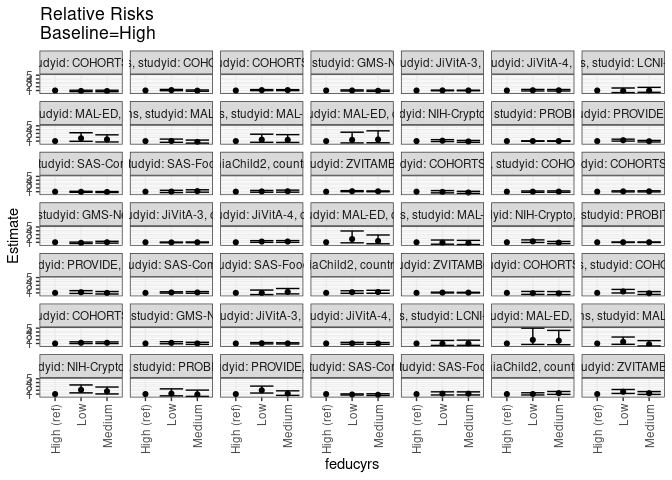

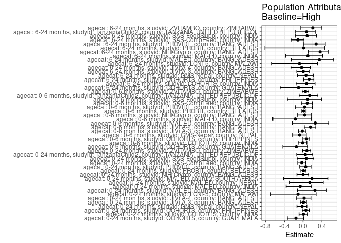

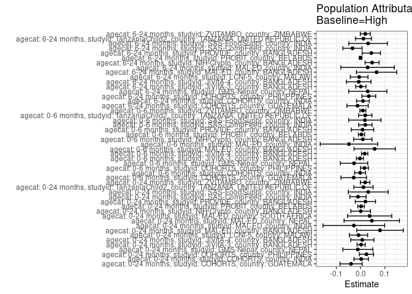

## Results Table

### Parameter: TSM

| agecat | studyid | country | intervention_level | baseline_level | estimate | ci_lower | ci_upper |
| --- | --- | --- | --- | --- | --- | --- | --- |
| 0-24 months | COHORTS | GUATEMALA | High | NA | 0.2994017 | 0.2477669 | 0.3510365 |
| 0-24 months | COHORTS | GUATEMALA | Low | NA | 0.2640491 | 0.2298721 | 0.2982261 |
| 0-24 months | COHORTS | GUATEMALA | Medium | NA | 0.2588867 | 0.2186574 | 0.2991159 |
| 0-24 months | COHORTS | INDIA | High | NA | 0.3340419 | 0.2959939 | 0.3720899 |
| 0-24 months | COHORTS | INDIA | Low | NA | 0.3708337 | 0.3299258 | 0.4117415 |
| 0-24 months | COHORTS | INDIA | Medium | NA | 0.3216883 | 0.2768206 | 0.3665559 |
| 0-24 months | COHORTS | PHILIPPINES | High | NA | 0.3772125 | 0.3432872 | 0.4111378 |
| 0-24 months | COHORTS | PHILIPPINES | Low | NA | 0.4149171 | 0.3790419 | 0.4507923 |
| 0-24 months | COHORTS | PHILIPPINES | Medium | NA | 0.4157580 | 0.3834465 | 0.4480695 |
| 0-24 months | GMS-Nepal | NEPAL | High | NA | 0.6020238 | 0.5315873 | 0.6724603 |
| 0-24 months | GMS-Nepal | NEPAL | Low | NA | 0.6071900 | 0.5520117 | 0.6623684 |
| 0-24 months | GMS-Nepal | NEPAL | Medium | NA | 0.5581275 | 0.4870371 | 0.6292178 |
| 0-24 months | JiVitA-3 | BANGLADESH | High | NA | 0.2551718 | 0.2374516 | 0.2728919 |
| 0-24 months | JiVitA-3 | BANGLADESH | Low | NA | 0.2617997 | 0.2488637 | 0.2747356 |
| 0-24 months | JiVitA-3 | BANGLADESH | Medium | NA | 0.2573860 | 0.2454837 | 0.2692882 |
| 0-24 months | JiVitA-4 | BANGLADESH | High | NA | 0.3029637 | 0.2516765 | 0.3542509 |
| 0-24 months | JiVitA-4 | BANGLADESH | Low | NA | 0.3225282 | 0.2919884 | 0.3530679 |
| 0-24 months | JiVitA-4 | BANGLADESH | Medium | NA | 0.3176750 | 0.2939260 | 0.3414240 |
| 0-24 months | LCNI-5 | MALAWI | High | NA | 0.0884817 | 0.0459005 | 0.1310628 |
| 0-24 months | LCNI-5 | MALAWI | Low | NA | 0.0782796 | 0.0465416 | 0.1100176 |
| 0-24 months | LCNI-5 | MALAWI | Medium | NA | 0.0874656 | 0.0538654 | 0.1210659 |
| 0-24 months | MAL-ED | BANGLADESH | High | NA | 0.2396393 | 0.1255016 | 0.3537770 |
| 0-24 months | MAL-ED | BANGLADESH | Low | NA | 0.4148413 | 0.2569723 | 0.5727104 |
| 0-24 months | MAL-ED | BANGLADESH | Medium | NA | 0.3443566 | 0.2136652 | 0.4750480 |
| 0-24 months | MAL-ED | INDIA | High | NA | 0.4972626 | 0.3457622 | 0.6487630 |
| 0-24 months | MAL-ED | INDIA | Low | NA | 0.5083028 | 0.3783183 | 0.6382874 |
| 0-24 months | MAL-ED | INDIA | Medium | NA | 0.3868536 | 0.2377543 | 0.5359528 |
| 0-24 months | MAL-ED | NEPAL | High | NA | 0.2804968 | 0.1388454 | 0.4221482 |
| 0-24 months | MAL-ED | NEPAL | Low | NA | 0.3880282 | 0.2018715 | 0.5741849 |
| 0-24 months | MAL-ED | NEPAL | Medium | NA | 0.3705222 | 0.1848694 | 0.5561750 |

[output cut: 117 more lines]

### Parameter: E(Y)

| agecat | studyid | country | intervention_level | baseline_level | estimate | ci_lower | ci_upper |
| --- | --- | --- | --- | --- | --- | --- | --- |
| 0-24 months | COHORTS | GUATEMALA | NA | NA | 0.2601297 | 0.2356425 | 0.2846169 |
| 0-24 months | COHORTS | INDIA | NA | NA | 0.3365584 | 0.3122030 | 0.3609138 |
| 0-24 months | COHORTS | PHILIPPINES | NA | NA | 0.4013250 | 0.3833827 | 0.4192673 |
| 0-24 months | GMS-Nepal | NEPAL | NA | NA | 0.5906433 | 0.5537666 | 0.6275199 |
| 0-24 months | JiVitA-3 | BANGLADESH | NA | NA | 0.2573354 | 0.2507501 | 0.2639207 |
| 0-24 months | JiVitA-4 | BANGLADESH | NA | NA | 0.3100246 | 0.2953385 | 0.3247108 |
| 0-24 months | LCNI-5 | MALAWI | NA | NA | 0.0799508 | 0.0612962 | 0.0986054 |
| 0-24 months | MAL-ED | BANGLADESH | NA | NA | 0.3197279 | 0.2440789 | 0.3953769 |
| 0-24 months | MAL-ED | INDIA | NA | NA | 0.4693878 | 0.3884360 | 0.5503395 |
| 0-24 months | MAL-ED | NEPAL | NA | NA | 0.3265306 | 0.2332088 | 0.4198524 |
| 0-24 months | MAL-ED | SOUTH AFRICA | NA | NA | 0.2000000 | 0.1249078 | 0.2750922 |
| 0-24 months | NIH-Crypto | BANGLADESH | NA | NA | 0.3298153 | 0.2963239 | 0.3633067 |
| 0-24 months | PROBIT | BELARUS | NA | NA | 0.2539381 | 0.1952340 | 0.3126422 |
| 0-24 months | PROVIDE | BANGLADESH | NA | NA | 0.3514286 | 0.3160364 | 0.3868207 |
| 0-24 months | SAS-CompFeed | INDIA | NA | NA | 0.4145695 | 0.3576236 | 0.4715155 |
| 0-24 months | SAS-FoodSuppl | INDIA | NA | NA | 0.4712919 | 0.4233811 | 0.5192026 |
| 0-24 months | TanzaniaChild2 | TANZANIA, UNITED REPUBLIC OF | NA | NA | 0.2366765 | 0.2196074 | 0.2537455 |
| 0-24 months | ZVITAMBO | ZIMBABWE | NA | NA | 0.2337854 | 0.2266636 | 0.2409072 |
| 0-6 months | COHORTS | GUATEMALA | NA | NA | 0.2006018 | 0.1757323 | 0.2254713 |
| 0-6 months | COHORTS | INDIA | NA | NA | 0.2462950 | 0.2238538 | 0.2687361 |
| 0-6 months | COHORTS | PHILIPPINES | NA | NA | 0.2291594 | 0.2137721 | 0.2445467 |
| 0-6 months | GMS-Nepal | NEPAL | NA | NA | 0.3771930 | 0.3408437 | 0.4135423 |
| 0-6 months | JiVitA-3 | BANGLADESH | NA | NA | 0.1757592 | 0.1700164 | 0.1815020 |
| 0-6 months | JiVitA-4 | BANGLADESH | NA | NA | 0.1079224 | 0.0978937 | 0.1179511 |
| 0-6 months | MAL-ED | BANGLADESH | NA | NA | 0.2244898 | 0.1568093 | 0.2921703 |
| 0-6 months | MAL-ED | INDIA | NA | NA | 0.2925170 | 0.2187257 | 0.3663083 |
| 0-6 months | NIH-Crypto | BANGLADESH | NA | NA | 0.2572559 | 0.2261171 | 0.2883948 |
| 0-6 months | PROBIT | BELARUS | NA | NA | 0.2485900 | 0.1897185 | 0.3074615 |
| 0-6 months | PROVIDE | BANGLADESH | NA | NA | 0.2585714 | 0.2261125 | 0.2910304 |
| 0-6 months | SAS-CompFeed | INDIA | NA | NA | 0.2197071 | 0.1750081 | 0.2644060 |
| 0-6 months | SAS-FoodSuppl | INDIA | NA | NA | 0.1866029 | 0.1492099 | 0.2239959 |
| 0-6 months | TanzaniaChild2 | TANZANIA, UNITED REPUBLIC OF | NA | NA | 0.1397398 | 0.1258162 | 0.1536634 |
| 0-6 months | ZVITAMBO | ZIMBABWE | NA | NA | 0.1794777 | 0.1729988 | 0.1859566 |
| 6-24 months | COHORTS | GUATEMALA | NA | NA | 0.1288889 | 0.1093000 | 0.1484778 |
| 6-24 months | COHORTS | INDIA | NA | NA | 0.1323843 | 0.1146569 | 0.1501118 |
| 6-24 months | COHORTS | PHILIPPINES | NA | NA | 0.2666667 | 0.2498425 | 0.2834908 |
| 6-24 months | GMS-Nepal | NEPAL | NA | NA | 0.4719864 | 0.4316361 | 0.5123367 |
| 6-24 months | JiVitA-3 | BANGLADESH | NA | NA | 0.1643382 | 0.1581062 | 0.1705701 |
| 6-24 months | JiVitA-4 | BANGLADESH | NA | NA | 0.2467286 | 0.2329282 | 0.2605290 |
| 6-24 months | LCNI-5 | MALAWI | NA | NA | 0.0773067 | 0.0588111 | 0.0958024 |
| 6-24 months | MAL-ED | BANGLADESH | NA | NA | 0.1908397 | 0.1232893 | 0.2583901 |
| 6-24 months | MAL-ED | INDIA | NA | NA | 0.2846715 | 0.2088306 | 0.3605124 |
| 6-24 months | NIH-Crypto | BANGLADESH | NA | NA | 0.1315068 | 0.1069744 | 0.1560393 |
| 6-24 months | PROBIT | BELARUS | NA | NA | 0.0083609 | 0.0045540 | 0.0121678 |
| 6-24 months | PROVIDE | BANGLADESH | NA | NA | 0.1609756 | 0.1319065 | 0.1900447 |
| 6-24 months | SAS-CompFeed | INDIA | NA | NA | 0.3051948 | 0.2633957 | 0.3469939 |
| 6-24 months | SAS-FoodSuppl | INDIA | NA | NA | 0.3557214 | 0.3088651 | 0.4025777 |
| 6-24 months | TanzaniaChild2 | TANZANIA, UNITED REPUBLIC OF | NA | NA | 0.1602787 | 0.1442326 | 0.1763249 |
| 6-24 months | ZVITAMBO | ZIMBABWE | NA | NA | 0.0946306 | 0.0890328 | 0.1002285 |

### Parameter: RR

| agecat | studyid | country | intervention_level | baseline_level | estimate | ci_lower | ci_upper |
| --- | --- | --- | --- | --- | --- | --- | --- |
| 0-24 months | COHORTS | GUATEMALA | High | High | 1.0000000 | 1.0000000 | 1.000000 |
| 0-24 months | COHORTS | GUATEMALA | Low | High | 0.8819224 | 0.7215435 | 1.077949 |
| 0-24 months | COHORTS | GUATEMALA | Medium | High | 0.8646799 | 0.6938641 | 1.077547 |
| 0-24 months | COHORTS | INDIA | High | High | 1.0000000 | 1.0000000 | 1.000000 |
| 0-24 months | COHORTS | INDIA | Low | High | 1.1101411 | 0.9558110 | 1.289390 |
| 0-24 months | COHORTS | INDIA | Medium | High | 0.9630177 | 0.8127969 | 1.141002 |
| 0-24 months | COHORTS | PHILIPPINES | High | High | 1.0000000 | 1.0000000 | 1.000000 |
| 0-24 months | COHORTS | PHILIPPINES | Low | High | 1.0999559 | 0.9742155 | 1.241925 |
| 0-24 months | COHORTS | PHILIPPINES | Medium | High | 1.1021850 | 0.9823717 | 1.236611 |
| 0-24 months | GMS-Nepal | NEPAL | High | High | 1.0000000 | 1.0000000 | 1.000000 |
| 0-24 months | GMS-Nepal | NEPAL | Low | High | 1.0085814 | 0.8733324 | 1.164776 |
| 0-24 months | GMS-Nepal | NEPAL | Medium | High | 0.9270854 | 0.7831753 | 1.097439 |
| 0-24 months | JiVitA-3 | BANGLADESH | High | High | 1.0000000 | 1.0000000 | 1.000000 |
| 0-24 months | JiVitA-3 | BANGLADESH | Low | High | 1.0259743 | 0.9447378 | 1.114196 |
| 0-24 months | JiVitA-3 | BANGLADESH | Medium | High | 1.0086773 | 0.9315874 | 1.092146 |
| 0-24 months | JiVitA-4 | BANGLADESH | High | High | 1.0000000 | 1.0000000 | 1.000000 |
| 0-24 months | JiVitA-4 | BANGLADESH | Low | High | 1.0645768 | 0.8808005 | 1.286697 |
| 0-24 months | JiVitA-4 | BANGLADESH | Medium | High | 1.0485580 | 0.8727552 | 1.259774 |
| 0-24 months | LCNI-5 | MALAWI | High | High | 1.0000000 | 1.0000000 | 1.000000 |
| 0-24 months | LCNI-5 | MALAWI | Low | High | 0.8846983 | 0.4716478 | 1.659482 |
| 0-24 months | LCNI-5 | MALAWI | Medium | High | 0.9885168 | 0.5345278 | 1.828091 |
| 0-24 months | MAL-ED | BANGLADESH | High | High | 1.0000000 | 1.0000000 | 1.000000 |
| 0-24 months | MAL-ED | BANGLADESH | Low | High | 1.7311074 | 0.9409720 | 3.184721 |
| 0-24 months | MAL-ED | BANGLADESH | Medium | High | 1.4369791 | 0.7806497 | 2.645116 |
| 0-24 months | MAL-ED | INDIA | High | High | 1.0000000 | 1.0000000 | 1.000000 |
| 0-24 months | MAL-ED | INDIA | Low | High | 1.0222020 | 0.6852916 | 1.524748 |
| 0-24 months | MAL-ED | INDIA | Medium | High | 0.7779664 | 0.4756029 | 1.272557 |
| 0-24 months | MAL-ED | NEPAL | High | High | 1.0000000 | 1.0000000 | 1.000000 |
| 0-24 months | MAL-ED | NEPAL | Low | High | 1.3833606 | 0.6828544 | 2.802481 |
| 0-24 months | MAL-ED | NEPAL | Medium | High | 1.3209500 | 0.6487840 | 2.689507 |

[output cut: 117 more lines]

### Parameter: PAR

| agecat | studyid | country | intervention_level | baseline_level | estimate | ci_lower | ci_upper |
| --- | --- | --- | --- | --- | --- | --- | --- |
| 0-24 months | COHORTS | GUATEMALA | High | NA | -0.0392721 | -0.0850862 | 0.0065421 |
| 0-24 months | COHORTS | INDIA | High | NA | 0.0025165 | -0.0272046 | 0.0322376 |
| 0-24 months | COHORTS | PHILIPPINES | High | NA | 0.0241125 | -0.0052698 | 0.0534948 |
| 0-24 months | GMS-Nepal | NEPAL | High | NA | -0.0113805 | -0.0730737 | 0.0503126 |
| 0-24 months | JiVitA-3 | BANGLADESH | High | NA | 0.0021636 | -0.0145608 | 0.0188881 |
| 0-24 months | JiVitA-4 | BANGLADESH | High | NA | 0.0070609 | -0.0408277 | 0.0549495 |
| 0-24 months | LCNI-5 | MALAWI | High | NA | -0.0085309 | -0.0460648 | 0.0290031 |
| 0-24 months | MAL-ED | BANGLADESH | High | NA | 0.0800886 | -0.0160304 | 0.1762076 |
| 0-24 months | MAL-ED | INDIA | High | NA | -0.0278748 | -0.1549582 | 0.0992086 |
| 0-24 months | MAL-ED | NEPAL | High | NA | 0.0460338 | -0.0680155 | 0.1600832 |
| 0-24 months | MAL-ED | SOUTH AFRICA | High | NA | 0.0372093 | -0.0540031 | 0.1284218 |
| 0-24 months | NIH-Crypto | BANGLADESH | High | NA | 0.0002911 | -0.0401741 | 0.0407564 |
| 0-24 months | PROBIT | BELARUS | High | NA | 0.0021530 | -0.0113826 | 0.0156886 |
| 0-24 months | PROVIDE | BANGLADESH | High | NA | 0.0197569 | -0.0219815 | 0.0614953 |
| 0-24 months | SAS-CompFeed | INDIA | High | NA | -0.0106544 | -0.0442024 | 0.0228935 |
| 0-24 months | SAS-FoodSuppl | INDIA | High | NA | 0.0315022 | -0.0507124 | 0.1137167 |
| 0-24 months | TanzaniaChild2 | TANZANIA, UNITED REPUBLIC OF | High | NA | 0.0117758 | -0.0278675 | 0.0514191 |
| 0-24 months | ZVITAMBO | ZIMBABWE | High | NA | 0.0186721 | -0.0009865 | 0.0383308 |
| 0-6 months | COHORTS | GUATEMALA | High | NA | -0.0283973 | -0.0810580 | 0.0242633 |
| 0-6 months | COHORTS | INDIA | High | NA | -0.0018032 | -0.0242926 | 0.0206861 |
| 0-6 months | COHORTS | PHILIPPINES | High | NA | 0.0159396 | -0.0003283 | 0.0322076 |
| 0-6 months | GMS-Nepal | NEPAL | High | NA | -0.0269997 | -0.0834408 | 0.0294414 |
| 0-6 months | JiVitA-3 | BANGLADESH | High | NA | -0.0028346 | -0.0169565 | 0.0112873 |
| 0-6 months | JiVitA-4 | BANGLADESH | High | NA | 0.0168662 | 0.0038360 | 0.0298964 |
| 0-6 months | MAL-ED | BANGLADESH | High | NA | 0.0578231 | -0.0271469 | 0.1427932 |
| 0-6 months | MAL-ED | INDIA | High | NA | -0.0480382 | -0.1663501 | 0.0702737 |
| 0-6 months | NIH-Crypto | BANGLADESH | High | NA | 0.0090366 | -0.0286416 | 0.0467148 |
| 0-6 months | PROBIT | BELARUS | High | NA | 0.0036220 | -0.0091722 | 0.0164162 |
| 0-6 months | PROVIDE | BANGLADESH | High | NA | 0.0079639 | -0.0383062 | 0.0542341 |
| 0-6 months | SAS-CompFeed | INDIA | High | NA | 0.0194764 | -0.0080999 | 0.0470528 |
| 0-6 months | SAS-FoodSuppl | INDIA | High | NA | 0.0176418 | -0.0489214 | 0.0842050 |
| 0-6 months | TanzaniaChild2 | TANZANIA, UNITED REPUBLIC OF | High | NA | 0.0191290 | -0.0083590 | 0.0466170 |
| 0-6 months | ZVITAMBO | ZIMBABWE | High | NA | 0.0094040 | -0.0028363 | 0.0216442 |
| 6-24 months | COHORTS | GUATEMALA | High | NA | -0.0123937 | -0.0562441 | 0.0314566 |
| 6-24 months | COHORTS | INDIA | High | NA | 0.0097366 | -0.0166315 | 0.0361047 |
| 6-24 months | COHORTS | PHILIPPINES | High | NA | 0.0338473 | 0.0053410 | 0.0623537 |
| 6-24 months | GMS-Nepal | NEPAL | High | NA | 0.0295248 | -0.0491874 | 0.1082369 |
| 6-24 months | JiVitA-3 | BANGLADESH | High | NA | 0.0009653 | -0.0202335 | 0.0221641 |
| 6-24 months | JiVitA-4 | BANGLADESH | High | NA | -0.0076216 | -0.0582394 | 0.0429963 |
| 6-24 months | LCNI-5 | MALAWI | High | NA | -0.0058614 | -0.0422880 | 0.0305652 |
| 6-24 months | MAL-ED | BANGLADESH | High | NA | 0.0658397 | -0.0173452 | 0.1490246 |
| 6-24 months | MAL-ED | INDIA | High | NA | 0.0288576 | -0.0812767 | 0.1389918 |
| 6-24 months | NIH-Crypto | BANGLADESH | High | NA | 0.0474338 | 0.0185891 | 0.0762785 |
| 6-24 months | PROBIT | BELARUS | High | NA | 0.0000814 | -0.0049575 | 0.0051204 |
| 6-24 months | PROVIDE | BANGLADESH | High | NA | 0.0442683 | 0.0067620 | 0.0817745 |
| 6-24 months | SAS-CompFeed | INDIA | High | NA | -0.0334301 | -0.0729935 | 0.0061333 |
| 6-24 months | SAS-FoodSuppl | INDIA | High | NA | 0.0309118 | -0.0484132 | 0.1102369 |
| 6-24 months | TanzaniaChild2 | TANZANIA, UNITED REPUBLIC OF | High | NA | 0.0116403 | -0.0212975 | 0.0445781 |
| 6-24 months | ZVITAMBO | ZIMBABWE | High | NA | 0.0194290 | -0.0013882 | 0.0402462 |

### Parameter: PAF

| agecat | studyid | country | intervention_level | baseline_level | estimate | ci_lower | ci_upper |
| --- | --- | --- | --- | --- | --- | --- | --- |
| 0-24 months | COHORTS | GUATEMALA | High | NA | -0.1509711 | -0.3421867 | 0.0130029 |
| 0-24 months | COHORTS | INDIA | High | NA | 0.0074771 | -0.0848696 | 0.0919630 |
| 0-24 months | COHORTS | PHILIPPINES | High | NA | 0.0600822 | -0.0160167 | 0.1304813 |
| 0-24 months | GMS-Nepal | NEPAL | High | NA | -0.0192681 | -0.1293258 | 0.0800641 |
| 0-24 months | JiVitA-3 | BANGLADESH | High | NA | 0.0084078 | -0.0587510 | 0.0713066 |
| 0-24 months | JiVitA-4 | BANGLADESH | High | NA | 0.0227753 | -0.1446828 | 0.1657356 |
| 0-24 months | LCNI-5 | MALAWI | High | NA | -0.1067016 | -0.6909247 | 0.2756695 |
| 0-24 months | MAL-ED | BANGLADESH | High | NA | 0.2504899 | -0.1163128 | 0.4967671 |
| 0-24 months | MAL-ED | INDIA | High | NA | -0.0593855 | -0.3679603 | 0.1795832 |
| 0-24 months | MAL-ED | NEPAL | High | NA | 0.1409786 | -0.2887883 | 0.4274329 |
| 0-24 months | MAL-ED | SOUTH AFRICA | High | NA | 0.1860465 | -0.4198366 | 0.5333827 |
| 0-24 months | NIH-Crypto | BANGLADESH | High | NA | 0.0008827 | -0.1296567 | 0.1163374 |
| 0-24 months | PROBIT | BELARUS | High | NA | 0.0084783 | -0.0459928 | 0.0601127 |
| 0-24 months | PROVIDE | BANGLADESH | High | NA | 0.0562188 | -0.0704377 | 0.1678891 |
| 0-24 months | SAS-CompFeed | INDIA | High | NA | -0.0257000 | -0.1119299 | 0.0538428 |
| 0-24 months | SAS-FoodSuppl | INDIA | High | NA | 0.0668422 | -0.1250950 | 0.2260355 |
| 0-24 months | TanzaniaChild2 | TANZANIA, UNITED REPUBLIC OF | High | NA | 0.0497550 | -0.1333840 | 0.2033013 |
| 0-24 months | ZVITAMBO | ZIMBABWE | High | NA | 0.0798687 | -0.0081246 | 0.1601816 |
| 0-6 months | COHORTS | GUATEMALA | High | NA | -0.1415607 | -0.4365963 | 0.0928831 |
| 0-6 months | COHORTS | INDIA | High | NA | -0.0073214 | -0.1029076 | 0.0799807 |
| 0-6 months | COHORTS | PHILIPPINES | High | NA | 0.0695570 | -0.0040589 | 0.1377756 |
| 0-6 months | GMS-Nepal | NEPAL | High | NA | -0.0715806 | -0.2324701 | 0.0683061 |
| 0-6 months | JiVitA-3 | BANGLADESH | High | NA | -0.0161279 | -0.0996867 | 0.0610818 |
| 0-6 months | JiVitA-4 | BANGLADESH | High | NA | 0.1562811 | 0.0266860 | 0.2686208 |
| 0-6 months | MAL-ED | BANGLADESH | High | NA | 0.2575758 | -0.2285454 | 0.5513444 |
| 0-6 months | MAL-ED | INDIA | High | NA | -0.1642236 | -0.6484487 | 0.1777624 |
| 0-6 months | NIH-Crypto | BANGLADESH | High | NA | 0.0351269 | -0.1230402 | 0.1710180 |
| 0-6 months | PROBIT | BELARUS | High | NA | 0.0145702 | -0.0378217 | 0.0643173 |
| 0-6 months | PROVIDE | BANGLADESH | High | NA | 0.0307998 | -0.1654745 | 0.1940200 |
| 0-6 months | SAS-CompFeed | INDIA | High | NA | 0.0886472 | -0.0363174 | 0.1985430 |
| 0-6 months | SAS-FoodSuppl | INDIA | High | NA | 0.0945420 | -0.3420179 | 0.3890885 |
| 0-6 months | TanzaniaChild2 | TANZANIA, UNITED REPUBLIC OF | High | NA | 0.1368901 | -0.0835253 | 0.3124677 |
| 0-6 months | ZVITAMBO | ZIMBABWE | High | NA | 0.0523963 | -0.0182590 | 0.1181490 |
| 6-24 months | COHORTS | GUATEMALA | High | NA | -0.0961584 | -0.4949821 | 0.1962691 |
| 6-24 months | COHORTS | INDIA | High | NA | 0.0735482 | -0.1480927 | 0.2524009 |
| 6-24 months | COHORTS | PHILIPPINES | High | NA | 0.1269275 | 0.0135718 | 0.2272569 |
| 6-24 months | GMS-Nepal | NEPAL | High | NA | 0.0625543 | -0.1199865 | 0.2153437 |
| 6-24 months | JiVitA-3 | BANGLADESH | High | NA | 0.0058738 | -0.1318660 | 0.1268517 |
| 6-24 months | JiVitA-4 | BANGLADESH | High | NA | -0.0308904 | -0.2577093 | 0.1550233 |
| 6-24 months | LCNI-5 | MALAWI | High | NA | -0.0758198 | -0.6669097 | 0.3056682 |
| 6-24 months | MAL-ED | BANGLADESH | High | NA | 0.3450000 | -0.2511462 | 0.6570944 |
| 6-24 months | MAL-ED | INDIA | High | NA | 0.1013715 | -0.3817356 | 0.4155660 |
| 6-24 months | NIH-Crypto | BANGLADESH | High | NA | 0.3606948 | 0.1123669 | 0.5395495 |
| 6-24 months | PROBIT | BELARUS | High | NA | 0.0097386 | -0.8155938 | 0.4598915 |
| 6-24 months | PROVIDE | BANGLADESH | High | NA | 0.2749997 | 0.0072984 | 0.4705102 |
| 6-24 months | SAS-CompFeed | INDIA | High | NA | -0.1095369 | -0.2560892 | 0.0199166 |
| 6-24 months | SAS-FoodSuppl | INDIA | High | NA | 0.0868990 | -0.1656747 | 0.2847461 |
| 6-24 months | TanzaniaChild2 | TANZANIA, UNITED REPUBLIC OF | High | NA | 0.0726254 | -0.1573143 | 0.2568799 |
| 6-24 months | ZVITAMBO | ZIMBABWE | High | NA | 0.2053140 | -0.0479009 | 0.3973421 |